# Can wearable signals flag nurse stress? Findings from the Nurse Stress Dataset

Data Analyst (R) technical assessment

## Summary

Wrist-worn Empatica E4 data from 15 hospital nurses (609 session files, about 1,250 hours) were matched to the stress level each nurse reported for specific work periods. **After allowing for which nurse was recording, average skin conductance, heart rate, skin temperature and movement did not reliably separate high-stress from lower-stress periods.** Differences between nurses mattered more than differences in the signals. A wrist band alone is therefore a weak stress marker; personalised baselines are worth testing.

## Data and methods

**Signals and units.**

| Name | Full name | Unit | Native rate |
| --- | --- | --- | --- |
| EDA | Electrodermal activity (skin conductance) | microsiemens (uS) | 4 Hz |
| HR | Heart rate | beats per minute (bpm) | 1 Hz |
| TEMP | Skin temperature | degrees Celsius | 4 Hz |
| ACC (acc_mag) | Accelerometer movement magnitude | g (converted from raw counts) | 32 Hz |
| Stress level | Stress level reported by the nurse | 0, 1, 2 | one value per survey window |

Blood volume pulse (BVP), inter-beat interval (IBI) and button tags were not used. The participant called “E4” is a nurse ID and not the wristband.

**File structure.** Each nurse has a folder of session zips. Each zip holds `EDA`, `HR`, `TEMP` and `ACC` CSVs where line 1 is the Unix start time, line 2 the sample rate and the rest the data. `SurveyResults.xlsx` has one row per reported period: nurse ID, start and end time, date and a stress level (0, 1 or 2).

**Merging.** Every signal was averaged to 1 Hz (whole-second means) and outer-merged on the Unix second; the HR file starts 10 s later than the others. Each sensor second inherited the stress level of the survey window containing it (nurse ID plus start and end time, inclusive). Survey times are local hospital time, converted from `America/Chicago` to UTC after testing hourly offsets per nurse (see Appendix A9).

**Derived features.** `HR_sd60` (heart rate fluctuation: standard deviation over 60 s, a short-term proxy and not clinical heart rate variability), `EDA_phasic` (EDA minus its trailing 30 s mean, a fast-arousal proxy), `EDA_slope` (EDA change per second over 10 s), 60 s rolling means of heart rate and movement, and a local time-of-day segment (Morning 06-12, Afternoon 12-18, Evening/Night otherwise). Rolling windows are computed within each session so they never span recording breaks.

## Data Quality Considerations

[output not shown]

**Survey accounting.** 358 rows in the sheet; 113 without a stress level leaves 245 numeric rows; removing 3 duplicates leaves 242 distinct windows; 28 have no sensor data, leaving the 214 windows that were modelled.

## Correlation heatmap

Spearman correlation on 1-minute epochs, with pairwise deletion of missing values. Spearman was chosen because EDA and movement are skewed with outliers and relationships need only be monotonic. The stress row uses labelled epochs only. Every epoch counts equally here, so long survey windows weigh more than short ones; the model below weights each window once, so the two are not directly comparable.

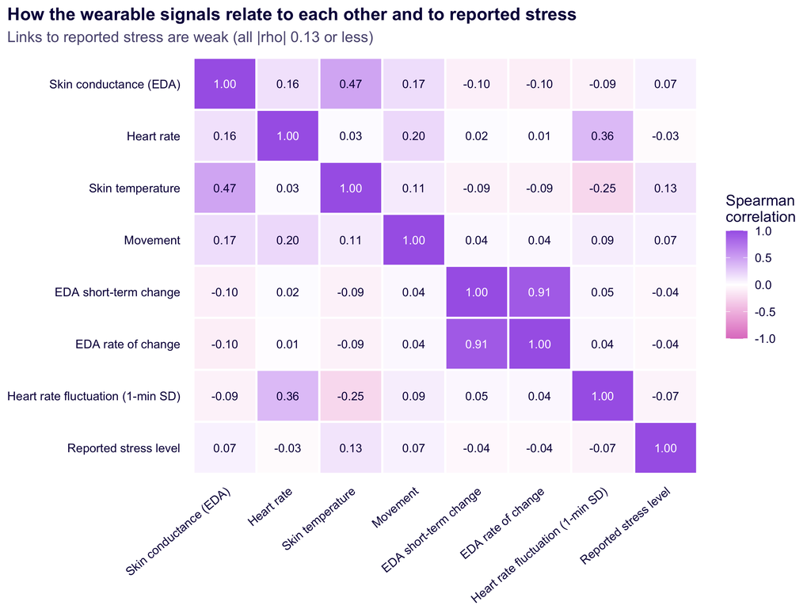

Spearman correlation of signals, derived features and reported stress.

- Skin temperature and EDA move together (rho 0.47), mostly reflecting wear and warmth.
- `EDA_phasic` and `EDA_slope` are almost the same measure (rho 0.91), so only `EDA_phasic` entered the model.
- Every correlation with reported stress is weak (|rho| of 0.13 or less; skin temperature highest).

## Statistical analysis

**Hypothesis.** H0: mean physiology during a survey window is unrelated to the window being rated high stress (level 2), after accounting for nurse. H1: higher arousal markers raise the odds of a high-stress window. Tests are two-sided at the 0.05 level.

**Method.** Mixed-effects logistic regression with a random intercept per nurse, one row per survey window (214 windows with at least 3 one-minute epochs; 161 high stress, 53 not), predictors scaled to 1 SD. Windows last 3 to 324 minutes (median 16) and each counts once. The label is constant within a window, so the window, not the minute, is the unit of analysis. A first model on minute-level rows with a nested window effect was rejected because the random effect absorbed the outcome (ICC 1.0).

**Assumption checks.** Variance inflation at most 1.45 (below 5: no collinearity concern); the model converged with no singular fit; binned residuals 80% inside bounds (95% preferred), so calibration is imperfect.

| Measure | Odds ratio per 1 SD | 95% CI low | 95% CI high | p |
| --- | --- | --- | --- | --- |
| Skin conductance (EDA) | 1.36 | 0.89 | 2.06 | 0.15 |
| Heart rate | 0.78 | 0.52 | 1.18 | 0.24 |
| Skin temperature | 1.08 | 0.69 | 1.70 | 0.73 |
| Movement | 0.82 | 0.56 | 1.22 | 0.33 |
| EDA short-term change | 0.88 | 0.55 | 1.42 | 0.60 |
| Heart rate fluctuation (1-min SD) | 1.04 | 0.70 | 1.56 | 0.83 |

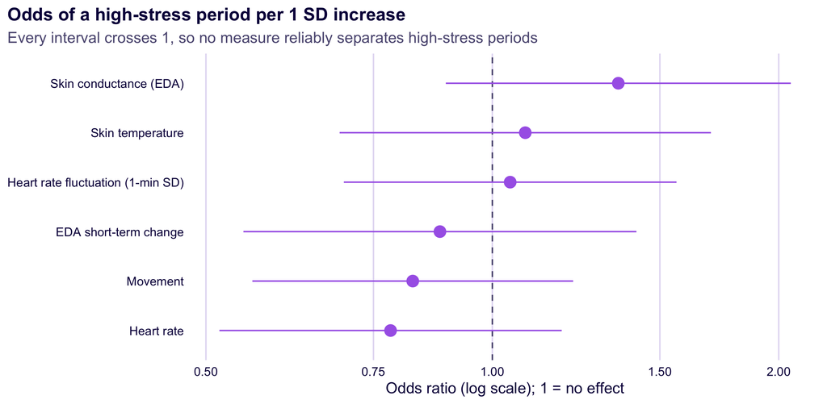

Odds ratios per 1 SD; 1 means no effect.

**Plain-language reading.** No signal was statistically significant and every interval includes 1. Skin conductance came closest (odds 1.36 per SD, 95% CI 0.89 to 2.06). Physiology explains about 5% of the variation in whether a window was high stress (marginal R2 0.046); adding nurse identity brings it to 21% (conditional R2 0.211, ICC 0.17).

## Insights

1. **Wrist signals alone are weak stress markers.** Correlations with reported stress are at most 0.13, and the window-level model is null.
2. **Who the nurse is matters more than the physiology.** About 17% of the variation in high versus lower stress windows sits between nurses, versus about 5% from the signals, which supports personalised baselines over one threshold for everyone.
3. **Reports are skewed and sparse.** 73% of distinct usable surveys (177 of 242) report the top stress level and only 7.9% of recorded time is labelled, which limits contrast for any model.

## Limitations and next steps

Only 214 labelled windows (53 not high stress) for six predictors, about 8.8 events per predictor; a single report per period; a dichotomised outcome (cutoff at level 2, level 1 sensitivity not yet run); window averages lose within-window dynamics and long windows (up to 324 minutes) count once like short ones; Cook’s distance flagged 13 windows but is unreliable for mixed logistic models; associations only. Most cutoffs below were not varied to test sensitivity, and the upper limits on temperature and EDA never triggered. Next: nurse-specific baselines, the survey’s stressor categories (for example patient crisis or workload), and validation on new nurses.

## Appendix A: Assumptions

[output not shown]

## Appendix B: Cutoffs and parameters

| Parameter | Value | Basis |
| --- | --- | --- |
| Heart rate plausible range | 30 to 220 bpm | Physiological limits; no values fell outside. |
| Skin temperature plausible range | 25 to 42 degrees C | Below 25 suggests off-wrist; 22,202 s removed, all below 25; none above 42. |
| EDA plausible range | 0.01 to 60 uS | Below 0.01 is consistent with no skin contact (not tested); 128,973 s (2.9%) removed, all below 0.01; none above 60 or 100 uS, so the upper limit never triggered. |
| Gap flagged as irregular | more than 5 s | None found within sessions. |
| Forward-fill limit | 5 s | See A14. |
| Rolling windows | HR mean 60 s, HR SD 60 s, EDA mean 30 s, movement 60 s | See A15. |
| EDA slope lag | 10 s | Short-term change. |
| Epoch length | 60 s | See A18. |
| Daily segments (local time) | 06-12, 12-18, otherwise Evening/Night | See A17. |
| Survey clock | America/Chicago to UTC | See A9. |
| Outcome cutoff (STRESS_CUT) | 2 | See A12. |
| Minimum epochs per window (MIN_EPOCHS) | 3 | See A19. |
| Correlation method | Spearman, pairwise deletion | Skewed signals; monotonic relationships. |
| Significance level | 0.05, two-sided Wald z; no correction for six tests | Standard default; exploratory. |
| Confidence intervals | 95%, Wald | broom.mixed default. |
| Optimiser | bobyqa, Laplace approximation | Stable convergence. |
| Collinearity check | VIF below 5 acceptable (maximum 1.45) | performance package default. |
| Residual check | about 95% of binned residuals inside bounds desired (observed 80%) | performance package default. |
| Outlier check | Cook’s distance 0.9 | performance default; unreliable for mixed logistic models. |

## Appendix C: Reconciliation and open items

**Resolved by re-running every script from scratch (all outputs reproduced exactly).**

1. All 609 session zips loaded; no session skipped.
2. The survey workbook has one sheet; the 113 dropped rows contain ‘na’ as the stress level.
3. The 31 surveys without labelled seconds are 28 with no sensor data plus 3 duplicate rows overwritten in overlaps.
4. The clock offset is 0 h for all 15 nurses.
5. The temperature and EDA upper limits never triggered; all removals were low readings.
6. The 3-epoch rule removed no windows.

**Still open.**

1. The stress-level coding (A12) is inferred, and the cause of the 113 ‘na’ rows is not stated in the data.
2. Level 1 sensitivity (cutoff at level 1) has not been run.
3. Whether the 28 missing recordings are device failures or upload gaps cannot be determined from the files.